# Applied microeconometrics

Week 3 - Discrete Choice

Josh Merfeld

KDI School

September 30, 2024

# Introduction

## What are we doing today?

- This week we will review methods for limited dependent variables
  - We will also discuss how to interpret the results
- Some of this will be review, but there will be some new stuff, too
  - For example, we will discuss poisson regression, which you might not have seen before

## What are we doing today?

- Much of the mathematical notation and theory comes from *Econometrics* by Bruce Hansen
  - I already discussed the older version of the textbook that is available for free online
- A small note:
  - You can use OLS for binary outcomes! This is actually pretty common in economics.
  - I’ll discuss this more in a bit.
  - Other disciplines (e.g. public health) really like some of the new methods we will discuss today, so they are worth knowing.

# Binary Choice

## Binary choice

- Let’s start with the simplest possibility: binary choice
- You can think of this as a No/Yes or False/True question, but we will generally refer to it as 0/1 choice
  - In programming, always remember that $FALSE=0$ and $TRUE=1$
- Focusing on the binary choice case will allow us to build intuition for the more general case of discrete choice
  - We will also be able to use the same data as we move to the more general case

## Dichotomous variables

- We will be thinking about this $Y\in\{0,1\}$
  - In other words, $Y$ is a dichotomous (dummy) variable that can only be equal to 0 or 1
- We are going to discuss methods to output *conditional probabilities*:
  $$\begin{gather} \mathbb{P}\left[Y=1|X\right] \end{gather}$$

## The error term

- Consider the following model:
  $$\begin{gather} Y = \beta X + \epsilon, \end{gather}$$
  where $X$ can have any number of columns (variables), $k$.
- We already know that $\epsilon$ does not need to be normally distributed
- In fact, if $Y\in\{0,1\}$, then $\epsilon$ *will never be normally distributed*
  - Why?

## The error term

- $\epsilon$ has a two-point conditional distribution:
  $$\begin{gather} \epsilon = \Biggl\{ \begin{array}{ll} 1 - P(X), & \text{with probability } P(X) \\ P(X), & \text{with probability } 1 - P(X) \end{array} \end{gather}$$
- $\epsilon$ is *heteroskedastic*:
  $$\begin{gather} \text{Var}(\epsilon|X) = P(X)(1-P(X)) \end{gather}$$
- In fact, the variance of any dummy variable is $P(1-P)$, where $P$ is the probability of the dummy variable being equal to 1

## Scatterplots are pretty worthless!

```r
# for reading in Stata data.
# Install this using your console
library(haven)
# read in data for the week:
df <- read_dta("data.dta")

# scatter of in_poverty on h_age:
ggplot(data = df) +
  geom_point(aes(x = h_age, y = in_poverty)) +
  labs(x = "Head age", y = "In poverty this month") +
  theme_bw() +
  theme(plot.background = element_rect(fill = "#f0f1eb", color = "#f0f1eb"))
```

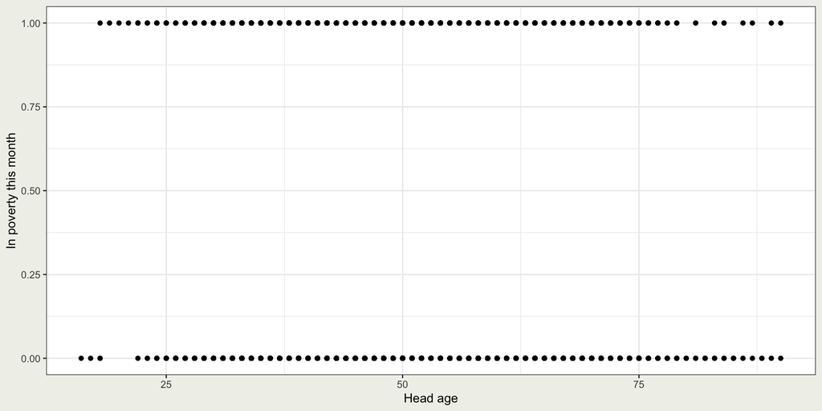

## Let’s plot out the conditional probabilities (means)

```r
# means by age
povmeans <- df %>%
            group_by(h_age) %>%
            summarize(mean = mean(in_poverty)) %>%
            ungroup

# scatter of in_poverty on h_age:
ggplot(data = povmeans) +
  geom_point(aes(x = h_age, y = mean)) +
  labs(x = "Head age", y = "P(poverty)") +
  theme_bw() +
  theme(plot.background = element_rect(fill = "#f0f1eb", color = "#f0f1eb"))
```

[figure not shown]

## Linear probability model (LPM)

- We can estimate this using OLS:
  $$\begin{gather} Y = \beta X + \epsilon \end{gather}$$

```r
f1 <- feols(in_poverty ~ h_male + h_age, data = df)
f2 <- feols(in_poverty ~ h_male + h_age, data = df, vcov = "HC1")
etable(f1, f2)
```

```
                                f1                 f2
Dependent Var.:         in_poverty         in_poverty

Constant        0.3523*** (0.0359) 0.3523*** (0.0372)
h_male           -0.0606* (0.0249)  -0.0606* (0.0260)
h_age            -4.96e-5 (0.0005)  -4.96e-5 (0.0006)
_______________ __________________ __________________
S.E. type                      IID Heteroskedas.-rob.
Observations                 4,609              4,609
R2                         0.00129            0.00129
Adj. R2                    0.00085            0.00085
---
Signif. codes: 0 '***' 0.001 '**' 0.01 '*' 0.05 '.' 0.1 ' ' 1
```

## Linear probability model (LPM)

```r
summary(feols(in_poverty ~ h_male + h_age, data = df, vcov = "HC1"))
```

```
OLS estimation, Dep. Var.: in_poverty
Observations: 4,609
Standard-errors: Heteroskedasticity-robust
             Estimate Std. Error   t value  Pr(>|t|)
(Intercept)  0.352347   0.037235  9.462735 < 2.2e-16 ***
h_male      -0.060625   0.025993 -2.332375  0.019724 *
h_age       -0.000050   0.000553 -0.089808  0.928443
---
Signif. codes:  0 '***' 0.001 '**' 0.01 '*' 0.05 '.' 0.1 ' ' 1
RMSE: 0.455294   Adj. R2: 8.54e-4
```

## Linear probability model (LPM)

- Sometimes people motivate other estimation methods based on heteroskedasticity
  - But we can easily correct for this using robust standard errors (HC1 in `feols`)
- There are two other problems with LPM, though:
- The predicted values can be outside of the 0-1 range
  - Is this a problem? Maybe. Maybe not. It depends on what you’re doing.
- Constant effects throughout the probability distribution
- Is this realistic? If we think someone has a 95 percent probability of being poor, do we think the percentage point change would be the same for changing a variable relative to someone with a 50 percent probability of being poor?

## Another option

- We can think of this as a *latent variable* model:
  $$\begin{gather} Y^* = \beta X + \epsilon \\
  \epsilon\sim G(\epsilon) \\
  Y = \mathbbm{1}(Y^*>0) = \Biggl\{ \begin{array}{ll} 1, & \text{if } Y^*>0 \\ 0, & \text{otherwise} \end{array} \end{gather}$$
  where $Y^*$ is the latent variable, $G(\cdot)$ is the distribution of $\epsilon$, and $\mathbbm{1}(\cdot)$ is the indicator function.
- One way to think about this is that $y^*$ is utility, but we only observe whether the choice increases utility ($y=1$) or doesn’t ($y=0$).

## Let’s give this a bit more structure

- Note that $Y=1$ iff $Y^*>0$, which is the same as saying $\beta X + \epsilon > 0$
- The response probability is then given by the CDF of $\epsilon$ evaluated at $-\beta X$:
  $$\begin{gather} \mathbb{P}\left[Y=1|X\right] = \mathbb{P}\left[\epsilon > -\beta X\right] = 1 - G(-\beta X) = G(\beta X) \end{gather}$$
- Note that CDFs (cumulative distribution functions) give us probabilities of being *less than or equal to* a given value
  - The last equality holds because $G(\cdot)$ will always be *symmetric around 0* here
  - That value here is $\beta X$

## CDF examples of the logistic (sigmoid) function - Wikipedia

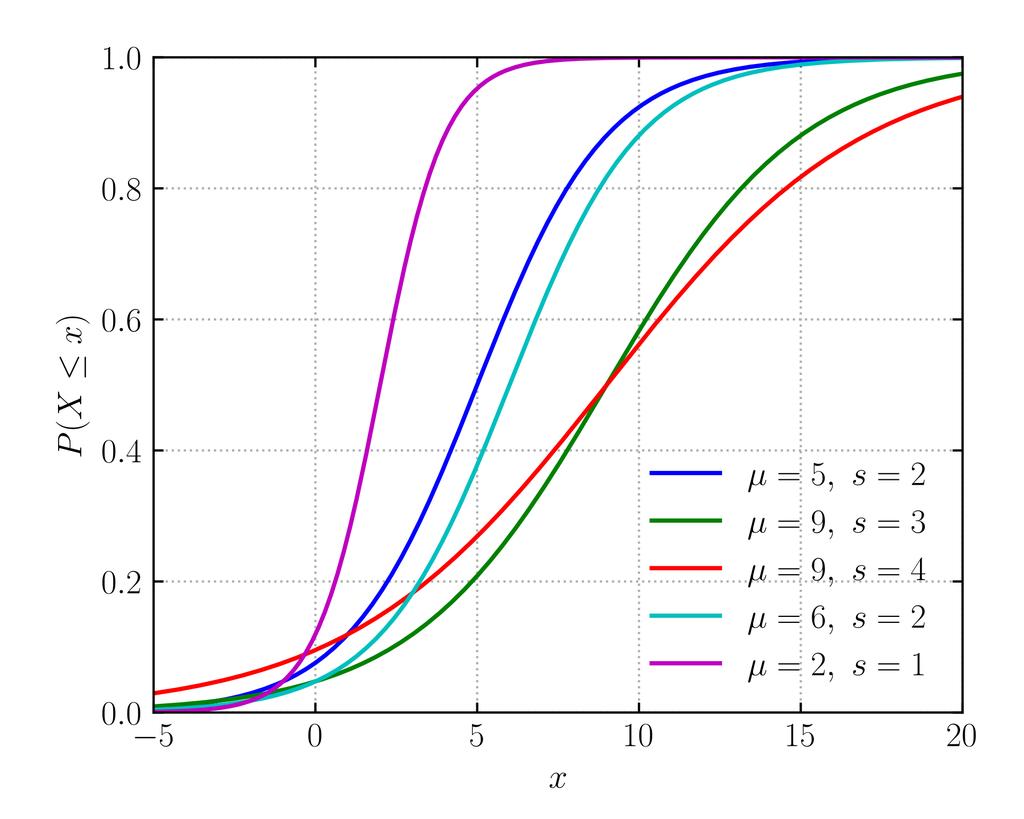

## The link function

- The function $G(\cdot)$ is called the *link function* and plays an important role here
- Two common link functions are the *logit* and *probit* link functions:
  - They are defined as follows:
  - Logit: $G(\epsilon) = \frac{e^{\epsilon}}{1+e^{\epsilon}} = \frac{1}{1+e^{-\epsilon}}$
  - Probit: $G(\epsilon) = \Phi(\epsilon)$, where $\Phi(\cdot)$ is the CDF of the standard normal distribution
- We will discuss these in more detail in a bit

## Likelihood

- Likelihood: the joint probability of the data evaluated with the sample, as a function of the parameters
  - What?
- Let’s start with probit, which uses a normal distribution. Here is the conditional density of $Y$ given $X$ under this assumption:
  $$\begin{gather} f(Y|X) = \frac{1}{\sqrt{2\pi\sigma^2}}\exp\left(-\frac{1}{2\sigma^2}(Y-\beta X)^2\right) \end{gather}$$

## Likelihood

$$\begin{gather} f(Y|X) = \frac{1}{\sqrt{2\pi\sigma^2}}\exp\left(-\frac{1}{2\sigma^2}(y-\beta X)^2\right) \end{gather}$$

- In this case, what is the probability we *observe our sample given the values of $\beta$ and $\sigma$*?
  $$\begin{align} f(y_1,\ldots,y_n | x_1,\ldots, x_n) &= \prod_{i=1}^n f(y_i | x_i) \\
  &= \prod_{i=1}^n \frac{1}{\sqrt{2\pi\sigma^2}}\exp\left(-\frac{1}{2\sigma^2}(y_i-\beta x_i)^2\right) \\
  &= \frac{1}{(2\pi\sigma^2)^{n/2}}\exp\left(-\frac{1}{2\sigma^2}\prod_{i=1}^n(y_i-\beta x_i)^2\right) \\
  &= L_n(\beta, \sigma^2) \end{align}$$

## Likelihood

$$\begin{gather} f(y_1,\ldots,y_n | x_1,\ldots, x_n) = L_n(\beta, \sigma^2) \end{gather}$$

- This is the *likelihood function*
  - Note that it is a function of the parameters, $\beta$ and $\sigma^2$
- The properties of logs make this easier to work with:
  $$\begin{gather} \ell_n(\beta, \sigma^2) = \log(L_n(\beta, \sigma^2)) = -\frac{n}{2}\log(2\pi\sigma^2) - \frac{1}{2\sigma^2}\sum_{i=1}^n(y_i-\beta x_i)^2 \end{gather}$$
- This is the *log likelihood function*
  - It is of course also a function of the parameters, $\beta$ and $\sigma^2$

## Maximum likelihood estimation

$$\begin{gather} \ell_n(\beta, \sigma^2) = \log(L_n(\beta, \sigma^2)) = -\frac{n}{2}\log(2\pi\sigma^2) - \frac{1}{2\sigma^2}\sum_{i=1}^n(y_i-\beta x_i)^2 \end{gather}$$

- We have our log likelihood function, which is a function of the parameters, $\beta$ and $\sigma^2$

## Maximum likelihood estimation

- What we want to do is find the values of $\beta$ and $\sigma^2$ that *maximize* this function
  - In other words, the values that make our sample the most likely to have been observed, or the biggest probability of observing our sample
- This is called *maximum likelihood estimation*

$$\begin{gather} \left(\hat{\beta}, \hat{\sigma}^2\right) = \underset{\beta\in\mathbb{R}^k,\sigma^2>0}{\text{argmax}}\;\ell_n(\beta, \sigma^2) \end{gather}$$
where $k$ is the number of variables (coefficients), including the intercept.

## Maximum likelihood estimation

- A simple example is a coin flip
- Let’s say we flip a coin. If it’s a fair coin, what is the probability of obtaining heads?

```
- 50% or 0.5 (we generally work with the proportion 0.5, and not the percent)
```

- What is the probability of obtaining heads twice in a row?

```
- 0.5 * 0.5 = 0.25
```

- Three times in a row?

```
- 0.5 * 0.5 * 0.5 = 0.125
```

## Maximum likelihood estimation

- Say we flip the coin a bunch of times
  - For argument’s sake, let’s say we flip it 100 times and obtain 60 heads
- If we know nothing about whether the coin is actually fair, what is the *most likely distribution* that would give us 60 heads and 40 tails?
  - It’s a distribution in which the probability of heads is 0.6!
- This is like maximum likelihood estimation. We are trying to find the parameters that makes our sample the most likely to have been observed.
  - In this case, the parameter would be the true mean of the distribution of the coin (where heads = 1 and tails = 0).
  - We could then of course test whether this is significantly different from 0.5, which might be our null hypothesis.

## Generalizing maximum likelihood estimation

$$\begin{gather} \left(\hat{\beta}, \hat{\sigma}^2\right) = \underset{\beta\in\mathbb{R}^k,\sigma^2>0}{\text{argmax}}\;\ell_n(\beta, \sigma^2) \end{gather}$$

- MLE is generally always estimated using numerical optimization
  - We will not discuss the details of this here
  - The basic reason is that most likelihood functions are not easy to maximize analytically (i.e. they have no closed-form solution)
- In the case of the normal regression model, however, there is a closed-form solution
  - And this is the same closed-form solution as OLS!

## Logit for binary choice

- Let’s return to our binary choice model.
  - Regardless of how you estimate it, the probability mass function for $Y$ is:

$$\begin{gather} \pi(y) = p^y(1-p)^{1-y}, \end{gather}$$
where $p$ is the probability of $Y=1$, or the mean. Remember that $Y\in\{0,1\}$; i.e., it can only equal 0 or 1.

- Let’s bring our link function back into it. The *conditional* probability is:
  $$\begin{gather} \pi(Y|X)=G(\beta X)^Y(1-G(\beta X))^{1-Y}=G(\beta X)^Y(G(-\beta X))^{1-Y}=G(\beta Z), \end{gather}$$

where $Z = \Biggl\{ \begin{array}{ll} X, & \text{if } Y=1 \\ -X, & \text{if } Y=0 \end{array}$

## Logit for binary choice

$$\begin{gather} \pi(Y|X)=G(\beta Z), \end{gather}$$

- Taking logs (because they’re easy to work with), we get the log likelihood function:
  $$\begin{gather} \ell_n(\beta) = \sum_{i=1}^n \log G(\beta Z) \end{gather}$$
- This is the same as the log likelihood function for probit, except that the link function is different.

## Logit for binary choice

- Again, we want to find the values of $\beta$ (and $\sigma$, which will show up in the link function) that maximize this function.
  $$\begin{gather} \left(\hat{\beta}, \hat{\sigma}^2\right) = \underset{\beta\in\mathbb{R}^k,\sigma^2>0}{\text{argmax}}\;\ell_n(\beta, \sigma^2) \end{gather}$$
- Something interesting is that in practice, we don’t numerically maximize…
  - Instead, we *minimize* the *negative* of the log likelihood function!

$$\begin{gather} \left(\hat{\beta}, \hat{\sigma}^2\right) = \underset{\beta\in\mathbb{R}^k,\sigma^2>0}{\text{argmin}}\;-\ell_n(\beta, \sigma^2) \end{gather}$$

## An example in R - Household variables and poverty using glm()

```r
summary(glm(in_poverty ~ h_male, data = df, family = binomial(link = "logit")))
```

```
Call:
glm(formula = in_poverty ~ h_male, family = binomial(link = "logit"),
    data = df)

Deviance Residuals:
    Min       1Q   Median       3Q      Max
-0.9280  -0.8263  -0.8263   1.5752   1.5752

Coefficients:
            Estimate Std. Error z value Pr(>|z|)
(Intercept)  -0.6196     0.1101  -5.631  1.8e-08 ***
h_male       -0.2796     0.1151  -2.428   0.0152 *
---
Signif. codes:  0 '***' 0.001 '**' 0.01 '*' 0.05 '.' 0.1 ' ' 1

(Dispersion parameter for binomial family taken to be 1)

    Null deviance: 5583.2  on 4608  degrees of freedom
Residual deviance: 5577.5  on 4607  degrees of freedom
AIC: 5581.5

Number of Fisher Scoring iterations: 4
```

## Interpreting logit output

```
              Estimate Std. Error   z value     Pr(>|z|)
(Intercept) -0.6196447  0.1100514 -5.630505 1.796828e-08
h_male      -0.2795628  0.1151389 -2.428047 1.518036e-02
```

- How do we interpret these coefficients?
  - The coefficients are “log odds”
- For male household heads, the log odds of being in poverty is 0.280 *lower* than that for female household heads
  - What?

## Log odds

- What are log odds?
  - Let’s start with odds:

$$\begin{gather} \text{odds} = \frac{p}{1-p}, \end{gather}$$

where $p$ is the probability of $y = 1$ (being poor in this case).

- Log odds?

$$\begin{gather} \text{log odds} = \log\left(\frac{p}{1-p}\right) \end{gather}$$

## Log odds and logit

- Logit regression is basically estimating:

$$\begin{gather} \log\left(\frac{p}{1-p}\right) = \beta_0 + \beta_1 X_1 + \ldots + \beta_k X_k \end{gather}$$

## The intercept is the log odds of being in poverty for female households

```
              Estimate Std. Error   z value     Pr(>|z|)
(Intercept) -0.6196447  0.1100514 -5.630505 1.796828e-08
h_male      -0.2795628  0.1151389 -2.428047 1.518036e-02
```

$$\begin{gather} \log\left(\frac{p}{1-p}\right) = -0.6196447 \\
\left(\frac{p}{1-p}\right) = exp(-0.6196447) \\
\left(\frac{p}{1-p}\right) \approx 0.538 \\
p = 0.538-0.538p \\
1.538p = 0.538 \\
p\approx 0.350 \end{gather}$$

What is the actual mean for female headed households? 0.35

## The coefficient?

$$\begin{gather} \log\left(\frac{p_m}{1-p_m}\right) - \log\left(\frac{p_f}{1-p_f}\right) = -0.2795628 \\
\log\left(\frac{\frac{p_m}{1-p_m}}{\frac{p_f}{1-p_f}}\right) = -0.2795628 \\
\left(\frac{\frac{p_m}{1-p_m}}{\frac{p_f}{1-p_f}}\right) = exp(-0.2795628) \\
\left(\frac{\frac{p_m}{1-p_m}}{\frac{p_f}{1-p_f}}\right) = 0.7561142 \end{gather}$$

- In the last line, this is referred to as an *odds ratio*.
  - It’s less than one, which means male-headed households are *less likely* to be in poverty.
  - Their *odds* of being in poverty are around 24% lower.

## The coefficient?

- Mean for female-headed households: 0.35
  - odds ($\frac{p_f}{1-p_f}$): 0.538
- Mean for male-headed households: 0.289
  - odds $\left(\frac{p_m}{1-p_m}\right)$: 0.407
- Odds ratio ($\frac{\frac{p_m}{1-p_m}}{\frac{p_f}{1-p_f}}$): 0.756
- Exponentiating shows us the odds ratio!

## Marginal effects

- We can also calculate marginal effects
  - These are the change in the probability of being in poverty for a one-unit change in the variable of interest
  - An important note is that this *depends on where you are located in the distribution*
- We just calculated the means, so with only the binary independent variable, we know that the marginal effect is:
  - -0.0606
- We will use the “mfx” package for this, so please install it in the console.

## Marginal effects

```r
logitmfx(in_poverty ~ h_male, data = df)
```

```
Call:
logitmfx(formula = in_poverty ~ h_male, data = df)

Marginal Effects:
           dF/dx Std. Err.       z   P>|z|
h_male -0.060649  0.025981 -2.3343 0.01958 *
---
Signif. codes:  0 '***' 0.001 '**' 0.01 '*' 0.05 '.' 0.1 ' ' 1

dF/dx is for discrete change for the following variables:

[1] "h_male"
```

```r
# for binary outcomes, it shows the change from 0 to 1!
```

## logit with more coefficients

```r
logitmfx(in_poverty ~ h_male + h_age, data = df)
```

```
Call:
logitmfx(formula = in_poverty ~ h_male + h_age, data = df)

Marginal Effects:
             dF/dx   Std. Err.       z   P>|z|
h_male -6.0623e-02  2.5982e-02 -2.3333 0.01963 *
h_age  -4.9739e-05  5.3672e-04 -0.0927 0.92616
---
Signif. codes:  0 '***' 0.001 '**' 0.01 '*' 0.05 '.' 0.1 ' ' 1

dF/dx is for discrete change for the following variables:

[1] "h_male"
```

```r
# for binary outcomes, it shows the change from 0 to 1!
# for continuous variables, it's the derivative (i.e. instantaneous change)!
# By default, it calculates these by holding variables AT THEIR MEANS
```

## Probit

```r
summary(glm(in_poverty ~ h_male, data = df, family = binomial(link = "probit")))$coefficients
```

```
              Estimate Std. Error   z value     Pr(>|z|)
(Intercept) -0.3856924 0.06759123 -5.706248 1.154935e-08
h_male      -0.1699918 0.07058912 -2.408188 1.603194e-02
```

## Standard normal CDF

- The intercept is -0.3856924
  - The mean poverty for female-headed households is 0.35
- Here’s the CDF for the standard normal distribution with the intercept:

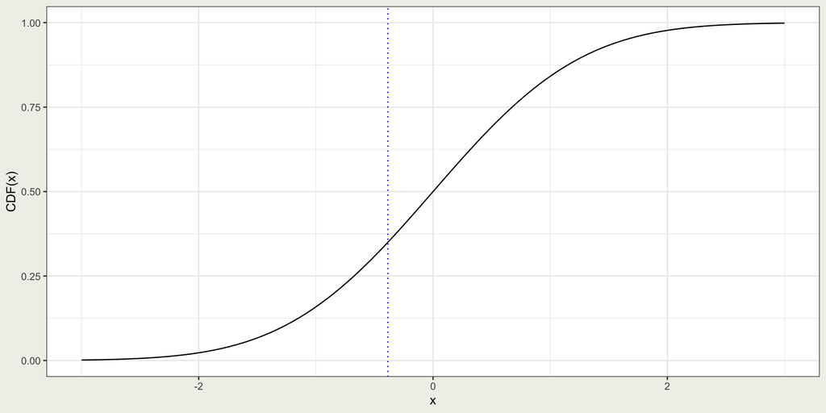

## Standard normal CDF

- The intercept is -0.3856924
  - The mean poverty for female-headed households is 0.35
- Here’s the CDF for the standard normal distribution with BOTH:

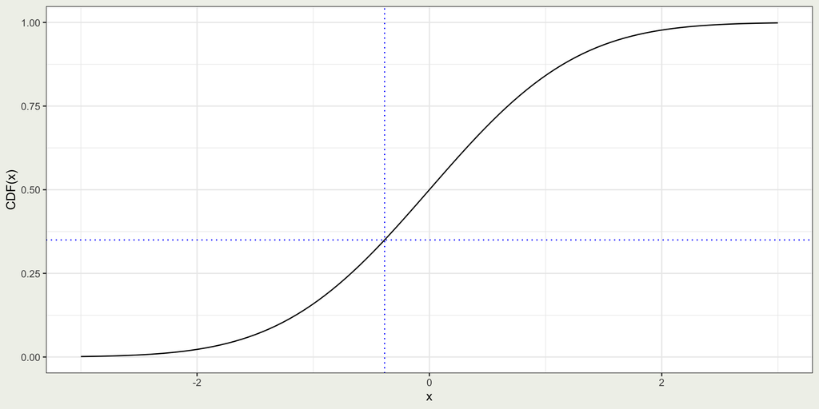

## Now let’s look at the coefficient on h_male

```r
summary(glm(in_poverty ~ h_male, data = df, family = binomial(link = "probit")))$coefficients
```

```
              Estimate Std. Error   z value     Pr(>|z|)
(Intercept) -0.3856924 0.06759123 -5.706248 1.154935e-08
h_male      -0.1699918 0.07058912 -2.408188 1.603194e-02
```

## Standard normal CDF

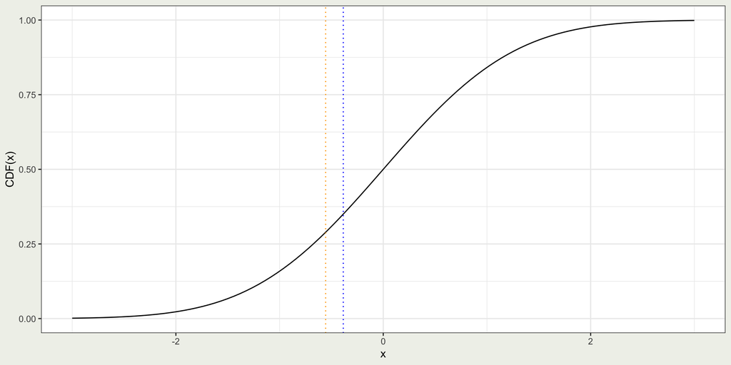

## Standard normal CDF

- The intercept is -0.3856924 and the coefficient is -0.1699918
- What’s the change in PROBABILITY? $\text{mean(male)} - \text{mean(female)}$ or -0.0606

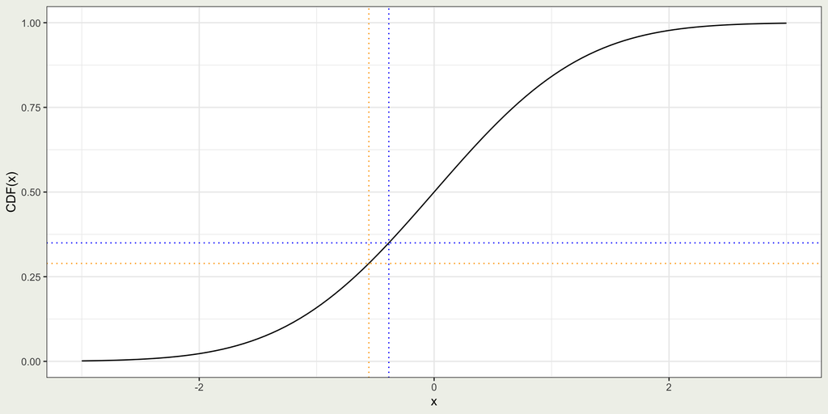

## Marginal effects

- The intercept is -0.3856924 and the coefficient is -0.1699918
- What’s the change in PROBABILITY? $\text{mean(male)} - \text{mean(female)}$ or -0.0606

```r
probitmfx(in_poverty ~ h_male, data = df)
```

```
Call:
probitmfx(formula = in_poverty ~ h_male, data = df)

Marginal Effects:
           dF/dx Std. Err.       z   P>|z|
h_male -0.060649  0.025981 -2.3343 0.01958 *
---
Signif. codes:  0 '***' 0.001 '**' 0.01 '*' 0.05 '.' 0.1 ' ' 1

dF/dx is for discrete change for the following variables:

[1] "h_male"
```

## Probit and marginal effects

```r
# change in z-scores
summary(glm(in_poverty ~ h_male + log(h_age), data = df, family = binomial(link = "probit")))$coefficients
```

```
               Estimate Std. Error    z value   Pr(>|z|)
(Intercept) -0.15654185 0.30328127 -0.5161606 0.60574222
h_male      -0.16978359 0.07059221 -2.4051321 0.01616662
log(h_age)  -0.05896973 0.07611372 -0.7747582 0.43848254
```

```r
# change in probability, holding other variables at their means
probitmfx(in_poverty ~ h_male + log(h_age), data = df)
```

```
Call:
probitmfx(formula = in_poverty ~ h_male + log(h_age), data = df)

Marginal Effects:
               dF/dx Std. Err.       z   P>|z|
h_male     -0.060570  0.025980 -2.3314 0.01973 *
log(h_age) -0.020308  0.026211 -0.7748 0.43848
---
Signif. codes:  0 '***' 0.001 '**' 0.01 '*' 0.05 '.' 0.1 ' ' 1

dF/dx is for discrete change for the following variables:

[1] "h_male"
```

# Multiple discrete choice

## What if the outcome has more than two categories?

- Many outcomes are not 0/1.
- We can think of outcomes with discrete categories, but more than two:
  - Religion
  - Political party
  - Opinion on a likert scale (e.g. strongly agree, agree, neutral, disagree, strongly disagree)
  - Months in poverty
- There’s a key difference between the first two and the last two:
  - The first two are *unordered*
  - The last two are *ordered*

## Months in poverty - distribution

```r
ggplot() +
    geom_histogram(data = df, aes(x = months_in_poverty), binwidth = 1) +
    theme_bw() +
    labs(x = "Months in poverty", y = "Count") +
    scale_x_continuous(breaks = seq(0, 12, 1)) +
    geom_vline(xintercept = mean(df$months_in_poverty), linetype = "dotted", color = "blue") +
  theme(plot.background = element_rect(fill = "#f0f1eb", color = "#f0f1eb"))
```

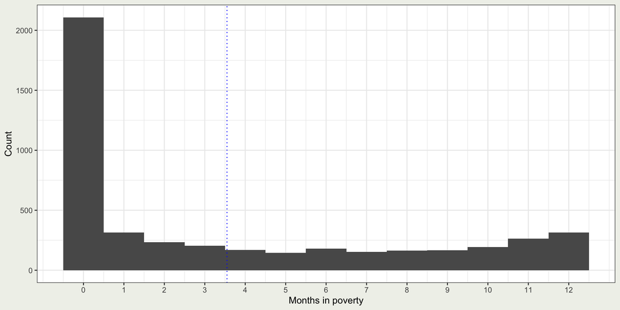

## Ordered logistic regression with the polr function

```r
# note that the outcome must be a FACTOR variable for polr
summary(polr(as_factor(months_in_poverty) ~ h_male + h_age, data = df, Hess = TRUE))
```

```
Call:
polr(formula = as_factor(months_in_poverty) ~ h_male + h_age,
    data = df, Hess = TRUE)

Coefficients:
            Value Std. Error  t value
h_male -0.3826883    0.10035 -3.81337
h_age   0.0001876    0.00216  0.08681

Intercepts:
      Value   Std. Error t value
0|1   -0.5168  0.1457    -3.5478
1|2   -0.2434  0.1455    -1.6730
2|3   -0.0376  0.1455    -0.2585
3|4    0.1472  0.1455     1.0119
4|5    0.3078  0.1455     2.1149
5|6    0.4514  0.1456     3.1004
6|7    0.6416  0.1458     4.4014
7|8    0.8171  0.1460     5.5975
8|9    1.0249  0.1463     7.0044
9|10   1.2665  0.1469     8.6198
10|11  1.6049  0.1482    10.8280
11|12  2.2775  0.1529    14.8999

Residual Deviance: 18592.59
AIC: 18620.59
```

## Ordered data: ordinal logit/probit

- When we have ordered discrete variable, we can use an ordered logit or probit model
  - These are also called *ordinal* logit/probit models
- The idea is that we have a latent variable, $Y^*$, that is continuous
  - We observe $Y$ as a discrete variable, but it is *ordered*
  - We can think of $Y$ as being *binned* into categories

$$\begin{gather} Y = \Biggl\{ \begin{array}{ll} 1, & \text{if } Y^*\in(-\infty,\theta_1] \\ 2, & \text{if } Y^*\in(\theta_1,\theta_2] \\ \vdots & \vdots \\ J, & \text{if } Y^*\in(\theta_{J-1},\infty) \end{array} \end{gather}$$

## The interpretation?

```
Call:
polr(formula = as_factor(months_in_poverty) ~ h_male + h_age,
    data = df, Hess = TRUE)

Coefficients:
            Value Std. Error  t value
h_male -0.3826883    0.10035 -3.81337
h_age   0.0001876    0.00216  0.08681

Intercepts:
      Value   Std. Error t value
0|1   -0.5168  0.1457    -3.5478
1|2   -0.2434  0.1455    -1.6730
2|3   -0.0376  0.1455    -0.2585
3|4    0.1472  0.1455     1.0119
4|5    0.3078  0.1455     2.1149
5|6    0.4514  0.1456     3.1004
6|7    0.6416  0.1458     4.4014
7|8    0.8171  0.1460     5.5975
8|9    1.0249  0.1463     7.0044
9|10   1.2665  0.1469     8.6198
10|11  1.6049  0.1482    10.8280
11|12  2.2775  0.1529    14.8999

Residual Deviance: 18592.59
AIC: 18620.59
```

- The interpretation is similar to logit: a change in the log-odds of being in a higher level of months in poverty!

## Understanding fit with MLE

- There is no r-squared in MLE
  - It is not a true r-squared *because there is no sense of “mean” with discrete data, especially unordered data*
- We can use the log likelihood function to compare models
  - The log likelihood function is a function of the parameters, $\beta$ and $\sigma^2$
  - The higher the log likelihood, the better the fit
- We can also use the *Akaike Information Criterion* (AIC) and *Bayesian Information Criterion* (BIC)
  - These are functions of the log likelihood function and the number of parameters
  - The lower the AIC/BIC, the better the fit
- These are best thought of as useful for comparing across models
  - Difficult to interpret them on their own

## AIC

- AIC is defined as follows:
  - $k$ is the number of parameters in the model
  - $L$ is the log likelihood function
  - AIC: $2k - 2\log(L)$

```r
# save our model
results <- glm(in_poverty ~ h_male + h_age, data = df, family = binomial(link = "probit"))

# log likelihood
logLik(results)
```

```
'log Lik.' -2788.727 (df=3)
```

```r
# aic from temp
results$aic
```

```
[1] 5583.453
```

```r
# Calculate AIC by hand:
2*3 - 2*(-2788.727)
```

```
[1] 5583.454
```

## BIC

- BIC is defined as follows:
  - $k$ is the number of parameters in the model
  - $L$ is the log likelihood function
  - $n$ is the number of observations
  - BIC: $k\log(n) - 2\log(L)$

```r
# save our model
results <- glm(in_poverty ~ h_male + h_age, data = df, family = binomial(link = "probit"))

# log likelihood
logLik(results)
```

```
'log Lik.' -2788.727 (df=3)
```

```r
nrow(df)
```

```
[1] 4609
```

```r
# Calculate BIC by hand:
3*log(4609) - 2*(-2788.727)
```

```
[1] 5602.761
```

## Pseudo r-squared

- We can also calculate a pseudo r-squared
  - This is a measure of the change in the log likelihood function relative to the null model (no coefficients except intercepts)

```r
# null model
logLik(glm(in_poverty ~ 1, data = df, family = binomial(link = "probit")))
```

```
'log Lik.' -2791.606 (df=1)
```

```r
# our model
logLik(glm(in_poverty ~ h_male + h_age, data = df, family = binomial(link = "probit")))
```

```
'log Lik.' -2788.727 (df=3)
```

```r
# pseudo r-squared: 1 - (log likelihood of model / log likelihood of null model)
1 - (-2788.727/-2791.606)
```

```
[1] 0.001031306
```

```r
# Same thing: (null - model) / null
(-2791.606 - -2788.727)/-2791.606
```

```
[1] 0.001031306
```

## Multinomial probit/logit

- Ordered logit/probit is used when the outcome is *ordered*
- But what if it’s not, like trying to predict what the species of a flower is?
  - Let’s use a built-in dataset in R called “iris” to look at this:

```r
data(iris)
head(iris)
```

```
  Sepal.Length Sepal.Width Petal.Length Petal.Width Species
1          5.1         3.5          1.4         0.2  setosa
2          4.9         3.0          1.4         0.2  setosa
3          4.7         3.2          1.3         0.2  setosa
4          4.6         3.1          1.5         0.2  setosa
5          5.0         3.6          1.4         0.2  setosa
6          5.4         3.9          1.7         0.4  setosa
```

## Multinomial probit/logit

```r
data(iris)
table(iris$Species)
```

```
    setosa versicolor  virginica
        50         50         50
```

```r
colnames(iris)
```

```
[1] "Sepal.Length" "Sepal.Width"  "Petal.Length" "Petal.Width"  "Species"
```

- Let’s use sepal/pedal length/width to predict the species

## Multinomial probit/logit

```r
data(iris)
library(nnet)
multinomresults <- multinom(Species ~ Sepal.Length + Sepal.Width + Petal.Length + Petal.Width, data = iris)
```

```r
summary(multinomresults)$coefficients
```

```
           (Intercept) Sepal.Length Sepal.Width Petal.Length Petal.Width
versicolor    18.69037    -5.458424   -8.707401     14.24477   -3.097684
virginica    -23.83628    -7.923634  -15.370769     23.65978   15.135301
```

- Note how setosa isn’t there… it’s the omitted category
  - We can interpret the coefficients as the log odds of being in a particular category relative to setosa (the omitted category)

# Extensions

## Extensions

- GLM is a very general framework
  - We can use it for other distributions, too
- Let’s look at a poisson distribution
  - The poisson distribution is often used for count data
  - It has assumptions (mean = variance), but violation isn’t a big deal!

## The poisson distribution

- The poisson distribution is defined as follows:
  $$\begin{gather} f(y; \lambda) = \frac{\lambda^ye^{-\lambda}}{y!} \end{gather}$$
- Note the $e$: this is going to lead to a nice log interpretation
- $y$ is the number of occurrences of the variable (in our example, it will be number of months in poverty)
- As mentioned, one implication of this distribution is:
  $$\begin{gather} E(y) = Var(y) = \lambda \end{gather}$$
  i.e. the mean of $y$ equals its variance. But we can work around this if it’s false (which it probably is).

## Possion, months in poverty (with feols - feglm)

```r
# could save results. Not going to here... just display them
summary(feglm(months_in_poverty ~ h_male + h_age, data = df, family = "poisson"))
```

```
GLM estimation, family = poisson, Dep. Var.: months_in_poverty
Observations: 4,609
Standard-errors: IID
             Estimate Std. Error   t value  Pr(>|t|)
(Intercept)  1.456020   0.039857  36.53087 < 2.2e-16 ***
h_male      -0.277845   0.025915 -10.72158 < 2.2e-16 ***
h_age        0.001255   0.000625   2.00869   0.04457 *
---
Signif. codes:  0 '***' 0.001 '**' 0.01 '*' 0.05 '.' 0.1 ' ' 1
Log-Likelihood: -17,506.6   Adj. Pseudo R2: 0.00303
           BIC:  35,038.6     Squared Cor.: 0.004978
```

```r
# notice the difference in standard errors if we use HC1 (which we want to here because of overdispersion)
summary(feglm(months_in_poverty ~ h_male + h_age, data = df, family = "poisson", vcov = "HC1"))
```

```
GLM estimation, family = poisson, Dep. Var.: months_in_poverty
Observations: 4,609
Standard-errors: Heteroskedasticity-robust
             Estimate Std. Error   t value   Pr(>|t|)
(Intercept)  1.456020   0.092210 15.790222  < 2.2e-16 ***
h_male      -0.277845   0.057268 -4.851679 1.2242e-06 ***
h_age        0.001255   0.001487  0.844145 3.9859e-01
---
Signif. codes:  0 '***' 0.001 '**' 0.01 '*' 0.05 '.' 0.1 ' ' 1
Log-Likelihood: -17,506.6   Adj. Pseudo R2: 0.00303
           BIC:  35,038.6     Squared Cor.: 0.004978
```

## Interpreting poisson coefficients

```r
summary(feglm(months_in_poverty ~ h_male, data = df, family = "poisson", vcov = "HC1"))$coefficients
```

```
(Intercept)      h_male
  1.5189645  -0.2772304
```

- How do we interpret poisson coefficients?
  - They are the *log* of the *rate* of the outcome
  - i.e. the log of the number of months in poverty
- The log count for male-headed households is around 0.28 *lower* than for female-headed households

## The intercept is log count for female households

```r
summary(feglm(months_in_poverty ~ h_male, data = df, family = "poisson", vcov = "HC1"))$coefficients
```

```
(Intercept)      h_male
  1.5189645  -0.2772304
```

```r
# intercept is log count, so exponentiate for levels
exp(1.5189645)
```

```
[1] 4.567493
```

```r
# what is the mean for female-headed households?
mean(df$months_in_poverty[df$h_male==0])
```

```
[1] 4.567493
```

```r
# intercept plus coefficient for male-headed households
exp(1.5189645 - 0.2772304)
```

```
[1] 3.461611
```

```r
# mean for male-headed households?
mean(df$months_in_poverty[df$h_male==1])
```

```
[1] 3.461611
```

## Quasi-poisson

- The poisson distribution has a mean = variance assumption
  - This is often violated
  - We can use quasi-poisson instead
- The quasi-poisson is the same as poisson, but the variance is estimated from the data
  - With feglm, it estimates the variance as a *linear function of the mean*
- Small note: if you use glm, you can use the “quasipoisson” family
  - This is more similar to poisson with vcov = “HC1”!
    - If you use “HC1” in both, you’ll get identical results.
  - This is only about the structure of the error term. Not the coefficients.

## Possion vs quasi-poisson (note the similar standard errors with HC1 for poisson)

```r
# Poisson with HC1
summary(feglm(months_in_poverty ~ h_male + h_age, data = df, family = "poisson", vcov = "HC1"))
```

```
GLM estimation, family = poisson, Dep. Var.: months_in_poverty
Observations: 4,609
Standard-errors: Heteroskedasticity-robust
             Estimate Std. Error   t value   Pr(>|t|)
(Intercept)  1.456020   0.092210 15.790222  < 2.2e-16 ***
h_male      -0.277845   0.057268 -4.851679 1.2242e-06 ***
h_age        0.001255   0.001487  0.844145 3.9859e-01
---
Signif. codes:  0 '***' 0.001 '**' 0.01 '*' 0.05 '.' 0.1 ' ' 1
Log-Likelihood: -17,506.6   Adj. Pseudo R2: 0.00303
           BIC:  35,038.6     Squared Cor.: 0.004978
```

```r
# quasipoisson
summary(feglm(months_in_poverty ~ h_male + h_age, data = df, family = "quasipoisson"))
```

```
GLM estimation, family = quasipoisson, Dep. Var.: months_in_poverty
Observations: 4,609
Standard-errors: IID
             Estimate Std. Error   t value   Pr(>|t|)
(Intercept)  1.456020   0.091127 15.977892  < 2.2e-16 ***
h_male      -0.277845   0.059249 -4.689409 2.8192e-06 ***
h_age        0.001255   0.001429  0.878563 3.7968e-01
---
Signif. codes:  0 '***' 0.001 '**' 0.01 '*' 0.05 '.' 0.1 ' ' 1

  Squared Cor.: 0.004978
```

## Doesn’t have to be integers!

- You can use poisson for non-integer outcomes, too!
  - It’s just a distribution
  - It’s often used for integer outcomes because it’s a count distribution
- Jeff Wooldridge is a huge proponent of using (quasi) poisson
- Two really nice things: it is robust and has an easy interpretation

# Survival models

## Hazard/survival models

- These models are used for *duration* data
  - i.e. time until an event occurs or a state changes
  - e.g. time until death after being diagnosed with cancer, time until a person leaves poverty, time until a person gets a job, until contracting a disease, etc.
- You need a very specific kind of data for this…
  - We want to know what kinds of variables predict the occurence of some event (e.g. death).
- **Warning:** I am not an expert on survival models. I will give you a brief overview, but you should consult a textbook for more information.

## Pfizer-BioNTech COVID-19 vaccine

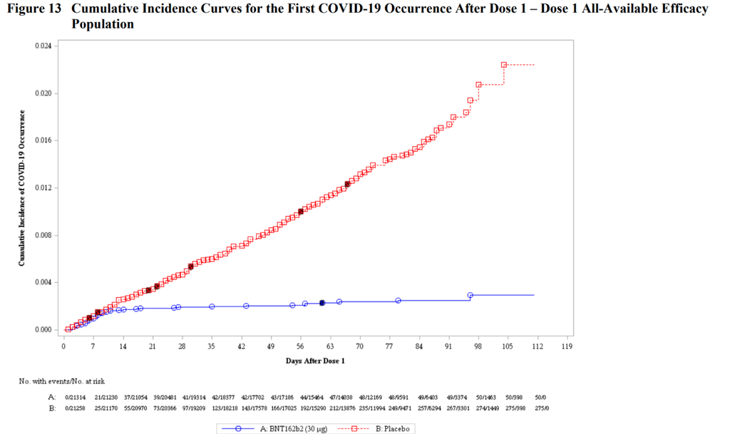

## Survival models

- Let’s use the package `survival` in R.
  - It has a dataset set up for us, called diabetic

```r
library(survival)
# dataset with "high-risk" diabetic retinopathy patients
head(diabetic)
```

```
  id laser age   eye trt risk  time status
1  5 argon  28  left   0    9 46.23      0
2  5 argon  28 right   1    9 46.23      0
3 14 xenon  12  left   1    8 42.50      0
4 14 xenon  12 right   0    6 31.30      1
5 16 xenon   9  left   1   11 42.27      0
6 16 xenon   9 right   0   11 42.27      0
```

- Note: this is a *panel* dataset
  - Each row is a patient (id)
  - Each patient has multiple observations (time)
  - Interested in loss of sight (status = 1)

## Survival function

- Let’s first look at the survival function
  - This is the probability of surviving past a certain time
  - We’re going to use the Kaplan-Meier estimator

```r
KM <- survfit(Surv(time = time, event = status) ~ 1, data = diabetic)
# note that Surv() is necessary here. It's a function that creates a survival object.
# The ~ 1 means this is for EVERYONE.
```

## Survival curve

```r
KM <- survfit(Surv(time = time, event = status) ~ 1, data = diabetic)
plot(KM, ylab = "Survival probability", xlab = "Time (months)")
```

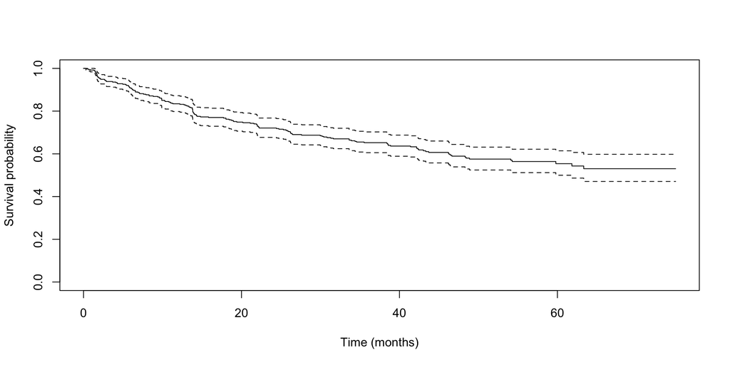

## Comparing survival curves based on treatment

- Base R has ugly plots. We can use `survminer` to make it work with `ggplot2`.

```r
library(survminer)
KM <- survfit(Surv(time = time, event = status) ~ 1, data = diabetic)
ggsurvplot(KM)$plot +
  labs(y = "Survival probability", x = "Time (months)") +
  theme(plot.background = element_rect(fill = "#f0f1eb", color = "#f0f1eb"))
```

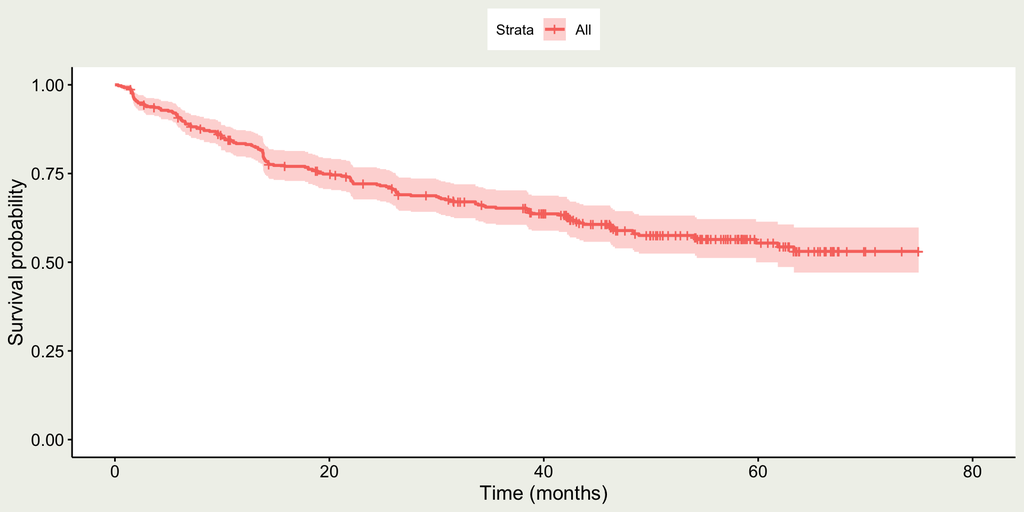

## Comparing survival curves based on treatment

```r
KM <- survfit(Surv(time = time, event = status) ~ trt, data = diabetic)
ggsurvplot(KM)$plot +
  labs(y = "Survival probability", x = "Time (months)") +
  scale_color_discrete("Treatment:", labels = c("No", "Yes")) +
  theme(legend.position = c(0.1, 0.2)) +
  theme(plot.background = element_rect(fill = "#f0f1eb", color = "#f0f1eb"))
```

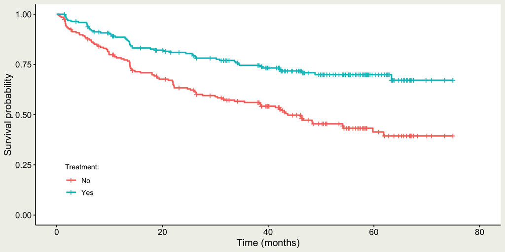

## Comparing survival curves based on treatment, empirically

```r
survdiff(Surv(time = time, event = status) ~ trt, data = diabetic)
```

```
Call:
survdiff(formula = Surv(time = time, event = status) ~ trt, data = diabetic)

        N Observed Expected (O-E)^2/E (O-E)^2/V
trt=0 197      101     71.8      11.9      22.2
trt=1 197       54     83.2      10.3      22.2

 Chisq= 22.2  on 1 degrees of freedom, p= 2e-06
```

```r
# changes the weighting (more weight on earlier time points); doesn't matter here! Huge differences.
survdiff(Surv(time = time, event = status) ~ trt, data = diabetic, rho = 1)
```

```
Call:
survdiff(formula = Surv(time = time, event = status) ~ trt, data = diabetic,
    rho = 1)

        N Observed Expected (O-E)^2/E (O-E)^2/V
trt=0 197     80.3     57.6      8.95      20.7
trt=1 197     43.1     65.8      7.84      20.7

 Chisq= 20.7  on 1 degrees of freedom, p= 6e-06
```

## Adding more covariates

- Plotting two survival curves with a simply treatment dummy is straightforward.
  - But what if we want to add more covariates?
  - For example, the `diabetic` dataset has age at diagnosis and which eye the problem is. Does this matter?
- We can use a Cox proportional hazards model to do this.
  - This is a semi-parametric model that is very popular in survival analysis.
  - It is a *proportional hazards* model, which means that the hazard ratio is constant over time.
  - Its nature means we do not estimate the baseline hazard function.
    - Instead, we compare across variables

## Adding more covariates

```r
coxph(Surv(time = time, event = status) ~ age + as_factor(eye) + trt, data = diabetic)
```

```
Call:
coxph(formula = Surv(time = time, event = status) ~ age + as_factor(eye) +
    trt, data = diabetic)

                         coef exp(coef)  se(coef)      z        p
age                  0.003321  1.003326  0.005463  0.608   0.5433
as_factor(eye)right  0.350484  1.419754  0.162537  2.156   0.0311
trt                 -0.812522  0.443738  0.169412 -4.796 1.62e-06

Likelihood ratio test=27.59  on 3 df, p=4.421e-06
n= 394, number of events= 155
```

- Note that treatment is randomized, so we *shouldn’t* see large changes in the coefficient on treatment when we add covariates.
  - More on this next week!

## Some warnings

- Note that all these methods have assumptions that can sometimes be important
- Given our time, I am purposefully just showing you the basics
  - If any of these specific methods interest you, I suggest doing more in-depth readings. I can provide some suggestions.

## Articles for next week (check syllabus for textbook readings)

- Deserranno, E., Stryjan, M., & Sulaiman, M. (2019). Leader selection and service delivery in community groups: Experimental evidence from Uganda. *American Economic Journal: Applied Economics*, 11(4), 240-267.
- Fischer, T., Frölich, M., & Landmann, A. (2023). Adverse Selection in Low-Income Health Insurance Markets: Evidence from an RCT in Pakistan. *American Economic Journal: Applied Economics*, 15(3), 313-340.